# 50 States Project

Marc Los Huertos

May 30, 2022

Updated: 2022-05-30 02:56:01

# Introduction

## Weather Records and Climate Trends

Human activities are driving climate change. And the impacts are being felt throughout the world — and in spite of or because of climate activists are organizing around the issue.

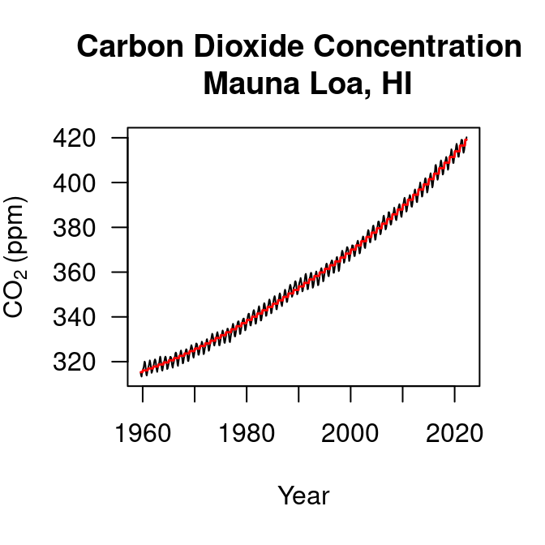

Observed CO<sub>2</sub> concentrations (black) have been steadily increasing since we have begun measuring them in the 1950s, with a best fit line (red). Note that the slope or the rate of change is also increasing.

# Fifty States Project

We ofen hear about the globe’s rising temperatures without learning much about how weather records in our own region might be contriubuting to these climate change patterns.

In most cases, a station in a state supports the overall global pattern, but in some we see patterns that are ambiguous or even contractory.

## Approach

For this project, I downloaded the longest and most complete record for each state and developed a standard set of analysis procedures and share them below.

I have also been working to create short videos that will be shared on various forms of social media.

For additional description of the project methods and R code, see ([Weather Station Records and Communicating Climate Change](https://github.com/marclos/Climate_Change_Narratives/raw/master/docs/Social_Media/States/Weather_Station_Records_and_Climate_Change.pdf))

# Basics in Analyzing Data

## Correlation and Causation

One of the most important parts of science is critical thinking, which begins with trying to root out logical falacies. One that comes up alot is the falacy that ``correlation is causation’’. In our case, many of the analysis included here are changes over time. Time in and of itself isn’t the cause of temperature or precipitation changes. Thus, we need to keep in mind, climate changes are due to complex dynanmics in the Earth System, which include natural and anthropocentric drivers.

## Statistical Considerations

In many cases, I will report the probability associated with correlations. However, these statistics obscure one of the hardest concepts in statistics: we test the null hypothesis, which might be “no change”. Thus, if the chances are low (< 5% change or 0.05 as a probability), we reject the null hypothesis and accept the altnernative, which in this case is “change”. Frankly, statistics is a bit like walking in a door backwards. You stil get in, but the path is less straightforward.

## Animated CO2 Records

Sometimes it’s a bit easier to see how these patterns develop over time and relative to what we think of as “pre-industrial” concentrations, which forms a base-line.

Although an animated figured can serve to show changes, it can also be distracting or hard to follow. For example, below I have a pretty straight forward image demonstrating the CO2 changes in Mauna Loa. I think this works pretty well, but I suspect not everyone would agree.

[figure not shown]

# States by Region

## Mid-West and Prairie States

### Kansas

(Kansas 2022)’s recorid is ambigous and possibly even contradictory and demonstrates the counter intuitive results at one location.

### Wisconson

(Wisconson 2022)’s recorid is ambigous and possibly even contradictory and demonstrates the counter intuitive results at one location.

## The South

### Alabama

(Alabama)’s recorid is ambigous and possibly even contradictory and demonstrates the counter intuitive results at one location.

### Texas

(Texas 2022)’s recorid is ambigous and possibly even contradictory and demonstrates the counter intuitive results at one location.

## Inter-Mountain West

### Utah

(Utah 2022)’s recorid is ambigous and possibly even contradictory and demonstrates the counter intuitive results at one location.

## Alaska and Hawaii

### Alaska

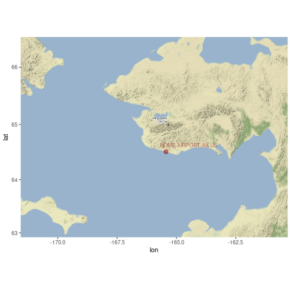

Station Location Map

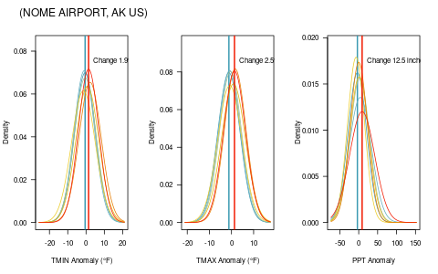

### Arizona

(Arizona 2022) is perplexing – the station with one of the longest records had a cooling trend. How can we explain this?

## Parallel issues in Europe and Asia